# Hipotesis 1

```r
library(tidyverse)
library(boot)
library(ggridges)
```

Eliminamos todos los casos donde no hay datos sobre el uso de horas reales de instagram.

```r
h1_dataset <- dataset_filtered %>% drop_na(uso_screnshot)
```

Como primera medida graficamos la relacion entre ambas variables

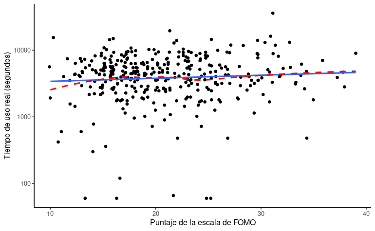

```r
linea_fit_plot <- ggplot(
  data = h1_dataset,
  aes(x = fomo_puntaje, y = uso_screnshot)
) +
  geom_jitter() +
  geom_smooth(method = 'lm', se = F) +
  geom_smooth(method = 'loess', color = 'red', se = F, linetype = 'dashed') +
  theme_classic() +
  scale_y_log10() +
  ylab('Tiempo de uso real (segundos)') + xlab('Puntaje de la escala de FOMO')
linea_fit_plot
ggsave('scater_h1.png')
```

En primer lugar calculamos la influencia de los valores individuales en la correlacion de Spearman calculando la correlacion sacando valores de a uno.

```r
loo_cor <- sapply(
  1:nrow(h1_dataset),
  function(x) cor(h1_dataset$fomo_puntaje[-x], h1_dataset$uso_screnshot[-x], method = 'spearman')
)
```

Despues dividimos estos valores a los de la correlacion con todos los datos y armamos un dataframe que tenga en una columna el resultado de la division y en otra columna el indice del sujeto eliminado. Si la division da por encima de uno entonces ese dato esta modificando la correlacion hacia valores mayores y si esta por debajo de 1 lo contrario.

```r
h1_loo_res <- tibble(correlacion_loo = loo_cor,
       diferencia = loo_cor/cor(h1_dataset$fomo_puntaje, h1_dataset$uso_screnshot, method = 'spearman'),
       indice = 1:nrow(h1_dataset))
```

Graficamos entonces el valor la variacion en la correlacion segun el indice del sujeto como el valor de la correlacion sin ese sujeto y el color segun la division antes descrita.

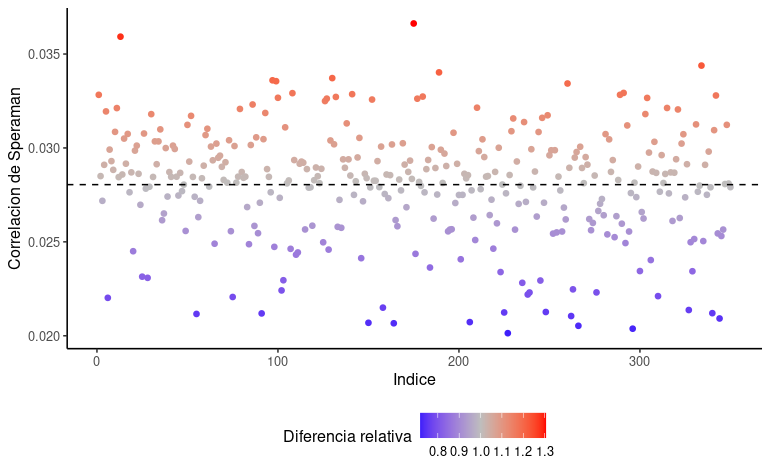

```r
loo_res_plot <- h1_loo_res %>% ggplot(
    aes(x = indice, y = correlacion_loo, color = diferencia)
  ) +
  geom_point() +
  geom_hline(
    yintercept = cor(h1_dataset$fomo_puntaje, h1_dataset$uso_screnshot, method = 'spearman'),
             linetype = 'dashed') +
  scale_color_gradient2('Diferencia relativa', low = 'blue', mid = 'grey', high = 'red', midpoint = 1) +
  theme_classic() +
  theme(legend.position = 'bottom') +
  ylab('Correlacion de Speraman') + xlab("Indice")
loo_res_plot
ggsave('loo_cor_h1.png')
```

No se observan valores altamente influyentes que pudieran preocuparnos. De ahora en mas entonces se realizaran los analisis utilizando la totalidad de los datos.

Corremos una correlacion de Spearman sobre los mismos datos.

```r
cor.test(h1_dataset$fomo_puntaje, h1_dataset$uso_screnshot, method = 'spearman')
```

```
    Spearman's rank correlation rho

data:  h1_dataset$fomo_puntaje and h1_dataset$uso_screnshot
S = 6945366, p-value = 0.601
alternative hypothesis: true rho is not equal to 0
sample estimates:
      rho
0.0280458
```

Los resultados son muy cercanos a 0 pero para obtener intervalos de confianza que nos permitan hacer inferencia con estos datos vamos a generar 10 mil muestras bootstrap provenientes de un bootstrap no parametrico calculando el estadistico de interes.

```r
corr_boot <- function(data, indices){
  boot_data <- data[indices,]
  spearman_value <- cor(boot_data$fomo_puntaje, boot_data$uso_screnshot, method = 'spearman')
  spearman_value
}

boot_test <- boot(
        data = h1_dataset,
        statistic = corr_boot,
        R = 10000,
        parallel = 'multicore',
        ncpus = 4
      )
```

Ahora calculamos intervalos de confianza

```r
boot.ci(boot_test)
```

```
BOOTSTRAP CONFIDENCE INTERVAL CALCULATIONS
Based on 10000 bootstrap replicates

CALL :
boot.ci(boot.out = boot_test)

Intervals :
Level      Normal              Basic
95%   (-0.0778,  0.1345 )   (-0.0777,  0.1357 )

Level     Percentile            BCa
95%   (-0.0797,  0.1338 )   (-0.0785,  0.1355 )
Calculations and Intervals on Original Scale
```

En todos los casos los intervalos nos indican que no hay señal de ninguna asociacion entre las variables.

Calculamos tambien cuantas muestras boostrap tuvieron valores por encima de 0.

```r
sum(boot_test$t > 0)/length(boot_test$t)
```

```
[1] 0.7022
```

Por ultimo podemos graficar la distribucion del estadistico para cada estadistico.

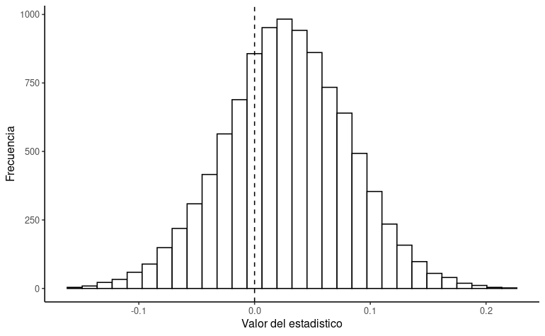

```r
boot_hist_plot <- ggplot(
  data = data.frame(x = boot_test$t), aes(x = x)) +
  geom_histogram(fill = 'white', color = 'black') +
  geom_vline(xintercept = 0, linetype = 'dashed') +
  theme_classic() +
  xlab("Valor del estadistico") + ylab("Frecuencia")
boot_hist_plot
ggsave('boot_h1.png')
```

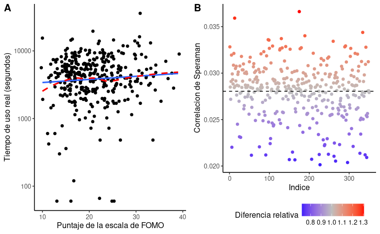

```r
ggarrange(
  linea_fit_plot, loo_res_plot,
  labels = c('A', 'B'),
  ncol = 2, nrow = 1
)
```

Ahora realizamos la misma correlacion pero excluyendo los sujetos que presentan inconsistencias en su respuesta

```r
cor.test(
  h1_dataset %>% filter(error_selfperception == F & error_otherperception == F) %>% pull(fomo_puntaje),
  h1_dataset %>% filter(error_selfperception == F & error_otherperception == F) %>% pull(uso_screnshot),
  method = 'spearman'
)
```

```
    Spearman's rank correlation rho

data:  h1_dataset %>% filter(error_selfperception == F & error_otherperception == F) %>% pull(fomo_puntaje) and h1_dataset %>% filter(error_selfperception == F & error_otherperception == F) %>% pull(uso_screnshot)
S = 1890985, p-value = 0.5211
alternative hypothesis: true rho is not equal to 0
sample estimates:
       rho
0.04271107
```

Calculamos los intervalos de confianza

```r
boot(
        data = h1_dataset %>% filter(error_selfperception == F & error_otherperception == F),
        statistic = corr_boot,
        R = 10000,
        parallel = 'multicore',
        ncpus = 4
      ) %>% boot.ci()
```

```
BOOTSTRAP CONFIDENCE INTERVAL CALCULATIONS
Based on 10000 bootstrap replicates

CALL :
boot.ci(boot.out = .)

Intervals :
Level      Normal              Basic
95%   (-0.0883,  0.1727 )   (-0.0890,  0.1731 )

Level     Percentile            BCa
95%   (-0.0876,  0.1745 )   (-0.0893,  0.1734 )
Calculations and Intervals on Original Scale
```